# Simple comparison between dimensionality reduction and clustering

yingying

November 20, 2018

```r
#install required packages
for (package in c('Rtsne', 'ggplot2')) {
    if (!require(package, character.only=T, quietly=T)) {
        install.packages(package)
        library(package, character.only=T)
    }
}
```

## Dimensionality reduction

### 1. PCA

The most common approach to PCA is via the Eigenvalue decomposition of the dataset’s covariance matrix. The amount of variance retained by each principal component is measured by eigenvalue.

The main purpose of PCA is to: * identify hidden pattern or overal shape of a dataset, identify which samples are similar to one another and which are very different. * reduce the dimensionnality of the data by removing the noise and redundency in the data * selection of features (variables) that make one group different from another * identify correlated variables

### 2. Practice PCA analysis

Gene expression matrix from RNA-Seq data analysis is high dimensional data. For example, sample i is defiend in 23113 (number of genes) dimensional space. Gene j is defined by a point in 14 (number of samples) dimensions.

```r
counts <- readRDS("counts_norm.rds")
dim(counts)
```

```
## [1] 23113    14
```

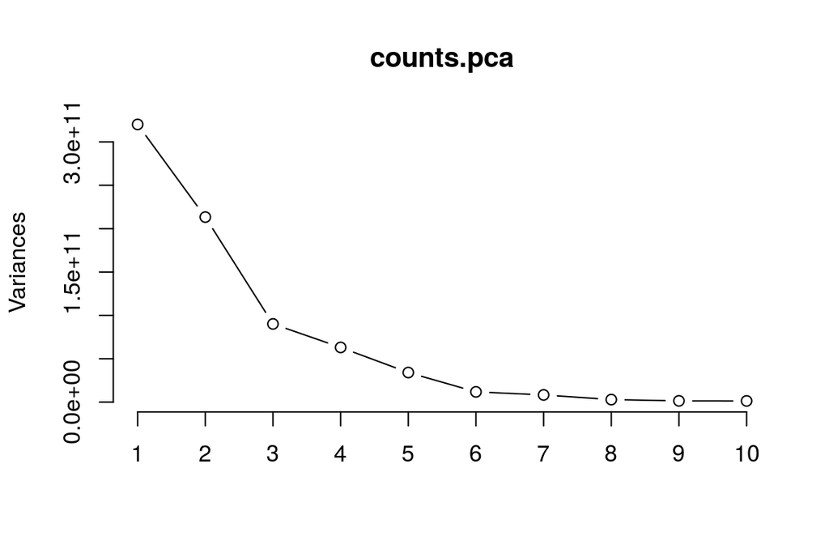

```r
data<-as.data.frame(t(counts))
counts.pca <- prcomp(t(counts))
plot(counts.pca,type="lines")
```

```r
summary(counts.pca)
```

```
## Importance of components:
##                              PC1       PC2       PC3       PC4       PC5
## Standard deviation     5.659e+05 4.619e+05 3.003e+05 2.511e+05 1.847e+05
## Proportion of Variance 4.279e-01 2.851e-01 1.205e-01 8.428e-02 4.560e-02
## Cumulative Proportion  4.279e-01 7.130e-01 8.334e-01 9.177e-01 9.633e-01
##                              PC6       PC7       PC8       PC9      PC10
## Standard deviation     1.088e+05 9.117e+04 5.425e+04 3.845e+04 3.742e+04
## Proportion of Variance 1.581e-02 1.111e-02 3.930e-03 1.980e-03 1.870e-03
## Cumulative Proportion  9.791e-01 9.902e-01 9.942e-01 9.961e-01 9.980e-01
##                             PC11      PC12      PC13      PC14
## Standard deviation     2.963e+04 2.199e+04 1.088e+04 1.575e-09
## Proportion of Variance 1.170e-03 6.500e-04 1.600e-04 0.000e+00
## Cumulative Proportion  9.992e-01 9.998e-01 1.000e+00 1.000e+00
```

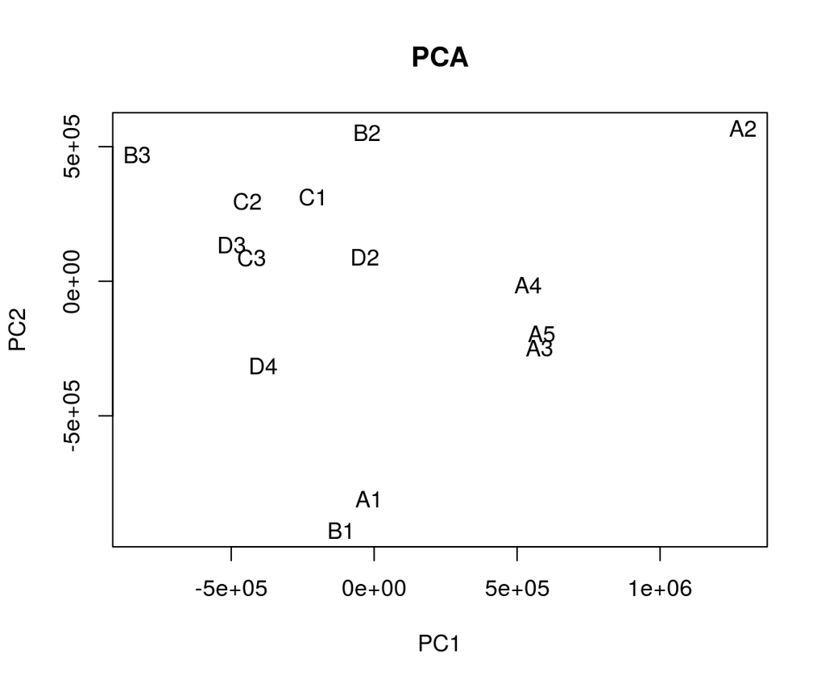

```r
plot(counts.pca$x[, 1], counts.pca$x[, 2], type = "n",main = "PCA", xlab = "PC1", ylab = "PC2", bty = "o")
text(counts.pca$x[, 1],counts.pca$x[, 2], labels = rownames(counts.pca$x))
```

### 2. MDS

```r
sqrt(sum(counts[,1]-counts[,2])^2) #distance between sample A1 and A2
```

```
## [1] 2571092
```

```r
sqrt(sum(counts[,1]-counts[,14])^2) #distance between A1 and D4
```

```
## [1] 349628.5
```

```r
#dist()computes the distance between each row, since we are interested in the distance between samples, we transpose the matrix
dis <- dist(t(counts), method = "euclidean" )
dis
```

```
##           A1        A2        A3        A4        A5        B1        B2
## A2 1953253.2
## A3  959298.2 1101775.5
## A4 1361192.4 1235712.1  770485.0
## A5 1372545.7 1253712.4  659252.1  574153.3
## B1  981044.9 2138283.8 1179580.2 1371929.9 1157640.7
## B2 1475678.1 1371138.0 1085689.1  996565.2 1142502.3 1561932.2
## B3 1664231.3 2153952.9 1613463.1 1532207.8 1622574.2 1644153.7  877688.6
## C1 1392483.3 1608467.5 1120119.7 1090633.9 1156870.3 1277300.3  523197.7
## C2 1418053.6 1798806.4 1215409.3 1184220.8 1210993.4 1385023.0  698630.4
## C3 1056432.0 1821935.2 1115592.8 1230394.8 1323098.7 1345138.1  743424.1
## D2 1222091.3 1614878.1 1054870.7  756942.3 1089517.0 1387910.4  814841.5
## D3 1220440.5 1873888.1 1212166.1 1386929.8 1344458.1 1289781.3  776400.5
## D4 1227676.3 2068968.8 1223467.6 1112421.8 1153853.2 1210269.3 1256784.1
##           B3        C1        C2        C3        D2        D3
## A2
## A3
## A4
## A5
## B1
## B2
## B3
## C1  762090.4
## C2  492957.4  583220.2
## C3  748605.5  774192.5  619601.9
## D2 1096017.0  876070.2  869658.5  863675.2
## D3  705395.0  729480.6  592924.8  514621.4 1055756.8
## D4 1098467.6 1155403.1  827536.0  918245.8  897351.6 1096907.7
```

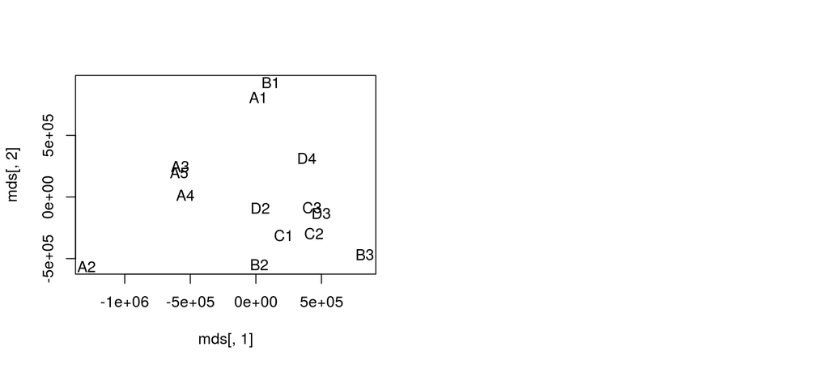

```r
mds <- cmdscale(dis)
par(mfrow=c(1,2))
plot(mds[, 1], mds[, 2],type="n")
text(mds[, 1],mds[, 2], labels = rownames(mds))
```

### 3. Comparison between PCA and MDS

Classic Torgerson’s metric MDS is actually done by transforming distances into similarities and performing PCA (eigen-decomposition or singular-value-decomposition) on those. [The other name of this procedure (distances between objects -> similarities between them -> PCA, whereby loadings are the sought-for coordinates) is Principal Coordinate Analysis or PCoA.] So, PCA might be called the algorithm of the simplest MDS.

### 4. tSNE

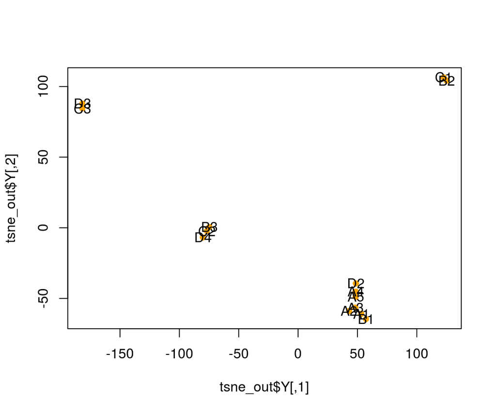

```r
library(Rtsne)
# Sets seed for reproducibility
set.seed(137)
# Remove duplicates
data <- t(unique(counts))
tsne_out <- Rtsne(data, dims = 2, perplexity = 1, verbose = FALSE)
plot(tsne_out$Y, pch=16, col="orange")
text(tsne_out$Y, rownames(data))
```

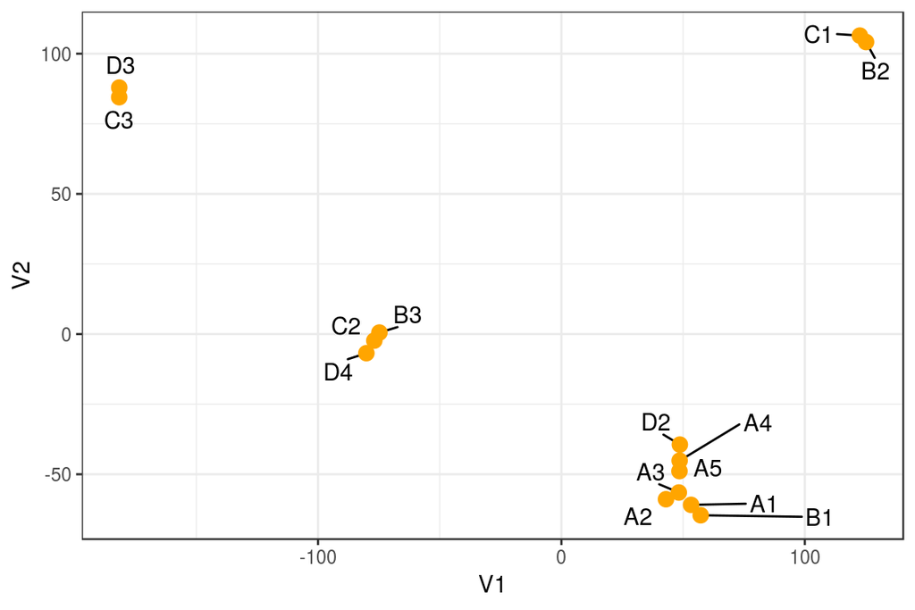

```r
library(ggplot2)
library(ggrepel)
ggplot(data = as.data.frame(tsne_out$Y), aes(x = V1, y = V2)) +
  theme_bw() +
  geom_text_repel(aes(label = rownames(data)), box.padding = unit(0.45, "lines")) +
  geom_point(colour = "orange", size = 3)
```

### 5. Comparison between PCA and tSNE

PCA is a technique for reducing the number of dimensions in a dataset whilst retaining most information. It is using the correlation between some dimensions and tries to provide a minimum number of variables that keeps the maximum amount of variation or information about how the original data is distributed. It does not do this using guesswork but using hard mathematics and it uses something known as the eigenvalues and eigenvectors of the data-matrix. These eigenvectors of the covariance matrix have the property that they point along the major directions of variation in the data. These are the directions of maximum variation in a dataset.

t-Distributed Stochastic Neighbor Embedding (t-SNE) is another technique for dimensionality reduction and is particularly well suited for the visualization of high-dimensional datasets. Contrary to PCA it is not a mathematical technique but a probablistic one. It is non-linear so it can capture the structure of trickier manifolds.

Essentially what this means is that it looks at the original data that is entered into the algorithm and looks at how to best represent this data using less dimensions by matching both distributions. The way it does this is computationally quite heavy and therefore there are some (serious) limitations to the use of this technique. For example one of the recommendations is that, in case of very high dimensional data, you may need to apply another dimensionality reduction technique before using t-SNE

## Clustering

### 1. hierarchical clustering

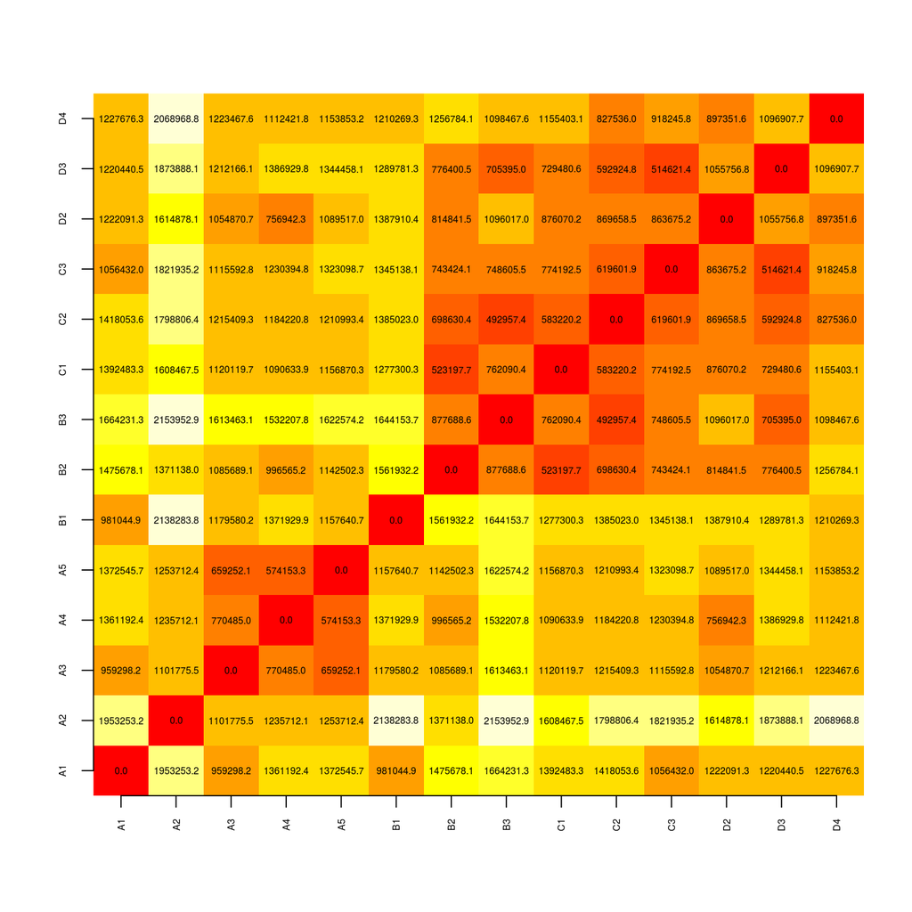

```r
dis <- dist(t(counts), method = "euclidean" )
#to access the entries using row and column indexes we need to coerce it into a matrix
dis2 <- as.matrix(dis)
dim <- ncol(dis2)
image(1:dim, 1:dim,dis2, axes=FALSE, xlab="",ylab="")
axis(1, 1:dim, colnames(dis2), cex.axis = 0.5, las=3)
axis(2, 1:dim, colnames(dis2), cex.axis = 0.5, las=3)
text(expand.grid(1:dim, 1:dim), sprintf("%0.1f", dis2), cex=0.5)
```

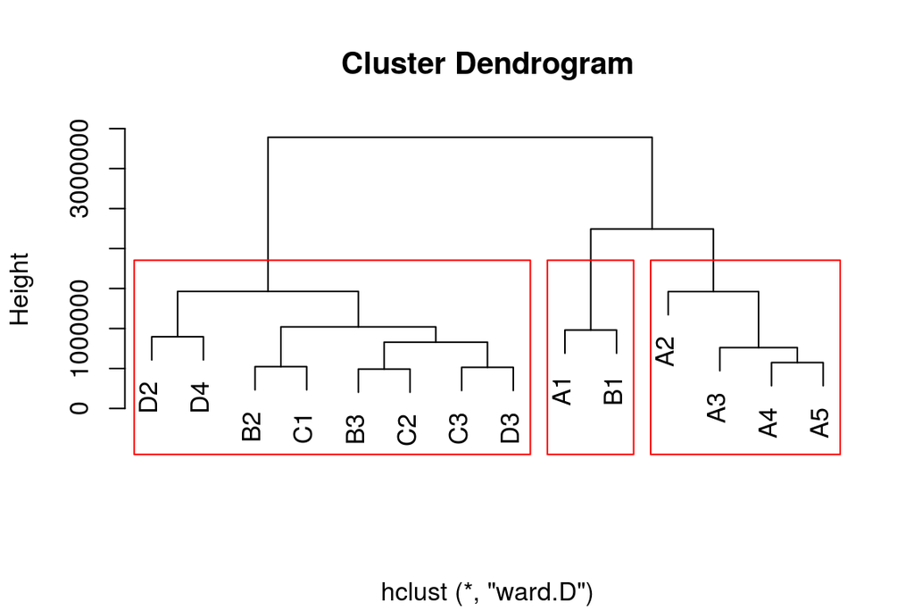

```r
clusters <- hclust(dis, method = "ward.D")
plot(clusters, xlab = "")
rect.hclust(clusters, k=3, border="red")
```

### 2. K-means clustering

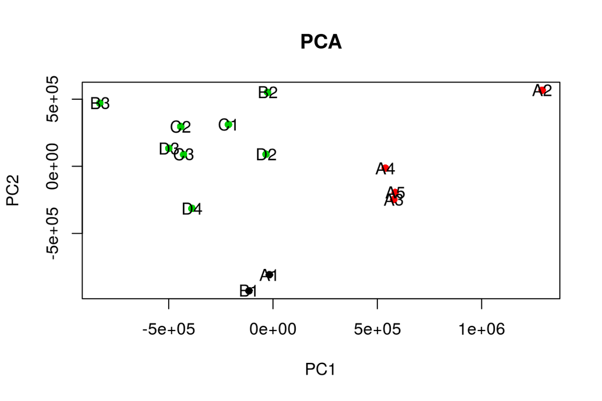

```r
set.seed(100)
data <- as.data.frame(t(counts))
k <- kmeans(data, 3)
data$cluster <- as.factor(k$cluster)

plot(counts.pca$x[, 1], counts.pca$x[, 2], col = data$cluster, pch = 16, main = "PCA", xlab = "PC1", ylab = "PC2")
text(counts.pca$x[, 1],counts.pca$x[, 2]+10, labels = rownames(counts.pca$x))
```

### 3. Heatmaps

Heatmaps are ubiquitous in the genomics literature. They are very useful plots for visualizing the measurements for a subset of rows over all the samples. A dendrogram is added on top and on the side that is created with hierarchical clustering.

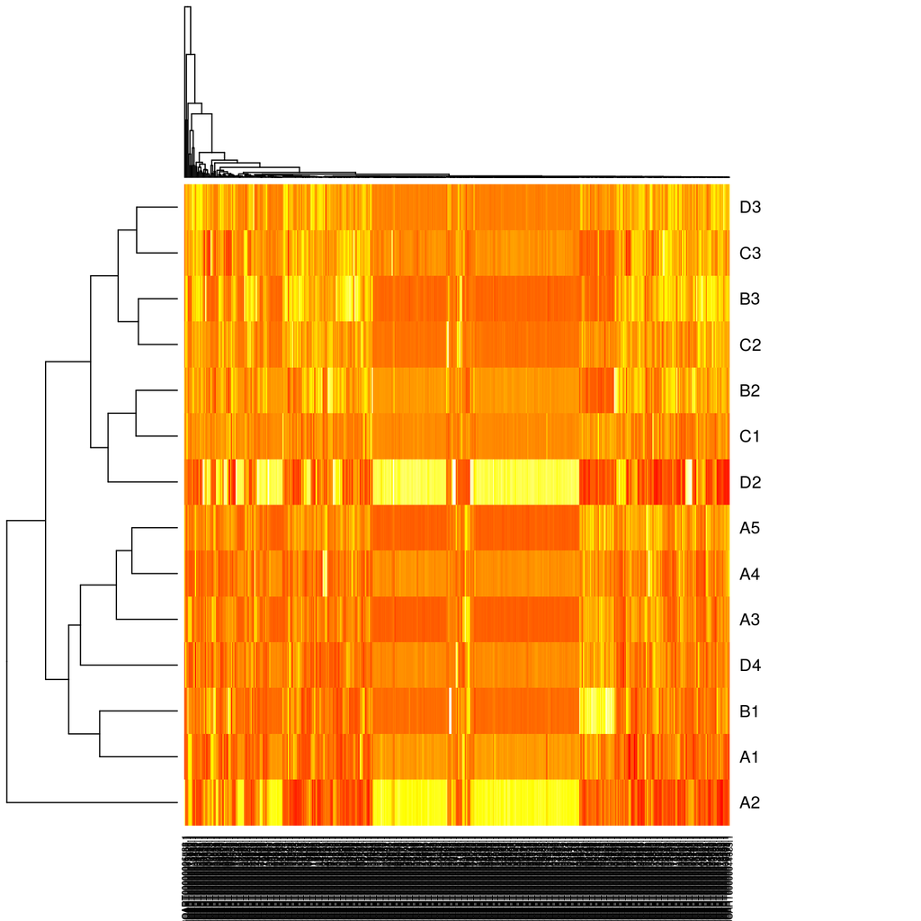

```r
#pick the genes with the top variance over all samples
library(genefilter)
rv <- rowVars(counts)
idx <- order(-rv)[1:500]
top500<-counts[idx,]

#make heatmap
top500.heatmap <- heatmap(t(top500), distfun = dist, hclustfun = hclust, col = heat.colors(200), scale="column", margins=c(5,10))
```

## Comparison between dimensionality reduction and clustering

Dimensionality reduction like PCA and and clustering like K-means do different things.

PCA is used for dimensionality reduction / feature selection / representation learning e.g. when the feature space contains too many irrelevant or redundant features. The aim is to find the intrinsic dimensionality of the data.

K-means is a clustering algorithm that returns the natural grouping of data points, based on their similarity.

PCA or other dimensionality reduction techniques are used before both unsupervised or supervised methods in machine learning. It is also used for visualization purposes (projection to 2D or 3D from higher dimensions).

PCA has no information regarding the natural grouping of data and operates on the entire data, not subsets (groups). If some groups might be explained by one eigenvector ( just because that particular cluster is spread along that direction ) is just a coincidence and shouldn’t be taken as a general rule.

“PCA aims at compressing the T features whereas clustering aims at compressing the N data-points.”

Clustering algorithm consists of the measurement of the similarity (or dissimilarity) between each pair of objects, and the choice of the similarity measure can have a large effect on the result. The goal of the clustering algorithm is then to partition the objects into homogeneous groups, such that the within-group similarities are large compared to the between-group similarities. The principal components, on the other hand, are extracted to represent the patterns encoding the highest variance in the data set and not to maximize the separation between groups of samples directly. However, in many high-dimensional real-world data sets, the most dominant patterns, i.e. those captured by the first principal components, are those separating different subgroups of the samples from each other. In this case, the results from PCA and hierarchical clustering support similar interpretations.